# Diamonds

In this notebook, we will do a brief exploration of some diamond data concluding with some price predictions based on attributes of the diamond.

First, let's import the necessary libraries.

```python
import os
import numpy as np
import pandas as pd
import matplotlib.pyplot as plt
from mpl_toolkits.mplot3d import Axes3D
import seaborn as sns
import hypertools as hyp
import plotly.offline as py

from sklearn.ensemble import RandomForestClassifier
from sklearn.ensemble import RandomForestRegressor
from sklearn.model_selection import train_test_split
from sklearn import linear_model

py.init_notebook_mode(connected=True)
import plotly.graph_objs as go
import plotly.tools as tls
from sklearn.feature_selection import mutual_info_classif
```

```python
%matplotlib inline
```

```python
cd
```

```
/Users/andrewvangilder
```

```python
cd Desktop/Python/Diamonds
```

```
/Users/andrewvangilder/Desktop/Python/Diamonds
```

Load the .csv files

```python
dmnd = pd.read_csv('diamonds.csv', low_memory=False, index_col=0)
```

Now we will some univariate exploration.

```python
dmnd.shape
```

```
(53940, 10)
```

```python
dmnd.head()
```

|  | carat | cut | color | clarity | depth | table | price | x | y | z |
| --- | --- | --- | --- | --- | --- | --- | --- | --- | --- | --- |
| 1 | 0.23 | Ideal | E | SI2 | 61.5 | 55.0 | 326 | 3.95 | 3.98 | 2.43 |
| 2 | 0.21 | Premium | E | SI1 | 59.8 | 61.0 | 326 | 3.89 | 3.84 | 2.31 |
| 3 | 0.23 | Good | E | VS1 | 56.9 | 65.0 | 327 | 4.05 | 4.07 | 2.31 |
| 4 | 0.29 | Premium | I | VS2 | 62.4 | 58.0 | 334 | 4.20 | 4.23 | 2.63 |
| 5 | 0.31 | Good | J | SI2 | 63.3 | 58.0 | 335 | 4.34 | 4.35 | 2.75 |

Distribution of the 'carat' attribute in this data set

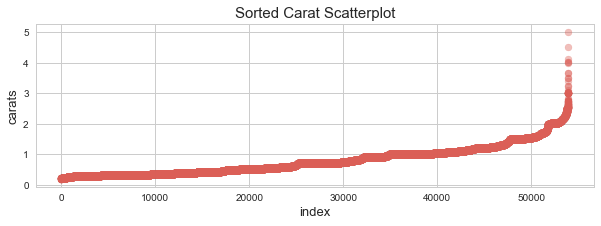

```python
plt.figure(figsize=(10,3))
plt.scatter(range(dmnd.shape[0]), np.sort(dmnd['carat'].values), alpha=.4)
plt.title('Sorted Carat Scatterplot', fontsize=15)
plt.xlabel('index', fontsize=13)
plt.ylabel('carats', fontsize=13)
plt.show()
```

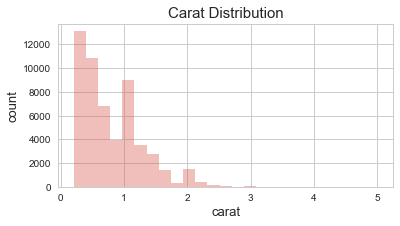

```python
plt.figure(figsize=(6,3))
sns.distplot(dmnd['carat'], bins=25, kde=False)
plt.title('Carat Distribution', fontsize=15)
plt.xlabel('carat', fontsize=13)
plt.ylabel('count', fontsize=13)
plt.show()
```

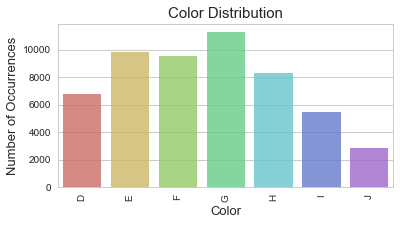

```python
val_count = dmnd['color'].value_counts()

plt.figure(figsize=(6,3))
sns.barplot(['D','E','F','G','H','I','J'],
            [val_count.values[4], val_count.values[1], val_count.values[2],
             val_count.values[0], val_count.values[3], val_count.values[5], val_count.values[6]], alpha=0.8)
plt.title('Color Distribution', fontsize=15)
plt.xticks(rotation='vertical')
plt.xlabel('Color', fontsize=13)
plt.ylabel('Number of Occurrences', fontsize=13)
plt.show()
```

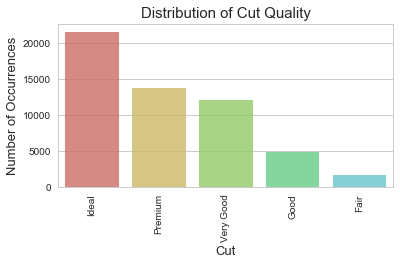

```python
val_count = dmnd['cut'].value_counts()

plt.figure(figsize=(6,3))
sns.barplot(val_count.index, val_count.values, alpha=0.8)
plt.title('Distribution of Cut Quality', fontsize=15)
plt.xticks(rotation='vertical')
plt.xlabel('Cut', fontsize=13)
plt.ylabel('Number of Occurrences', fontsize=13)
plt.show()
```

```python
val_count = dmnd['clarity'].value_counts()
val_count.index
```

```
Index(['SI1', 'VS2', 'SI2', 'VS1', 'VVS2', 'VVS1', 'IF', 'I1'], dtype='object')
```

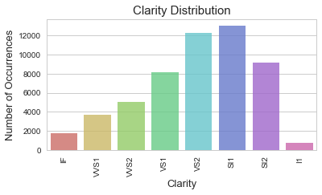

```python
val_count = dmnd['clarity'].value_counts()

plt.figure(figsize=(6,3))
sns.barplot(val_count.index, val_count.values, alpha=0.8, order=['IF','VVS1','VVS2','VS1','VS2','SI1','SI2','I1'])
plt.title('Clarity Distribution', fontsize=15)
plt.xticks(rotation='vertical')
plt.xlabel('Clarity', fontsize=13)
plt.ylabel('Number of Occurrences', fontsize=13)
plt.show()
```

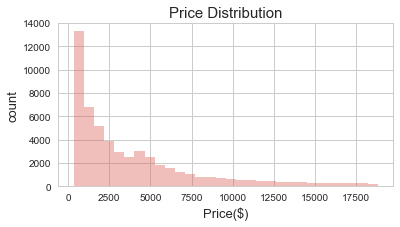

```python
plt.figure(figsize=(6,3))
sns.distplot(dmnd['price'], bins=30, kde=False)
plt.title('Price Distribution', fontsize=15)
plt.xlabel('Price($)', fontsize=13)
plt.ylabel('count', fontsize=13)
plt.show()
```

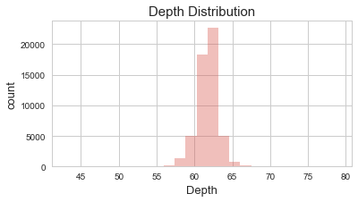

```python
plt.figure(figsize=(6,3))
sns.distplot(dmnd['depth'], bins=25, kde=False)
plt.title('Depth Distribution', fontsize=15)
plt.xlabel('Depth', fontsize=13)
plt.ylabel('count', fontsize=13)
plt.show()
```

Now let's see how these attributes relate and predict cost based on them.